# Lecture 3 Part 3

Stats 422

# Seaborn & plotnine

## Setup

```python
import numpy as np
import pandas as pd
import matplotlib.pyplot as plt
import matplotlib.colors as mcolors
import seaborn as sns
import plotnine as p9
from plotnine.data import mtcars

plt.rcParams['figure.figsize'] = [10, 5] # my default figure size for this lecture
plt.rcParams['figure.constrained_layout.use'] = True # supercedes tight layout
```

## Bring a little data in

```python
ikea = pd.read_csv('https://raw.githubusercontent.com/rfordatascience/tidytuesday/master/data/2020/2020-11-03/ikea.csv', usecols=lambda col: col != 'Unnamed: 0', index_col='item_id')
ikea['category'] = ikea['category'].astype('category')
ikea['other_colors'] = ikea['other_colors'].replace({'Yes': True, 'No': False})
ikea.info()
```

```
<class 'pandas.core.frame.DataFrame'>
Index: 3694 entries, 90420332 to 69157376
Data columns (total 12 columns):
 #   Column             Non-Null Count  Dtype
---  ------             --------------  -----
 0   name               3694 non-null   object
 1   category           3694 non-null   category
 2   price              3694 non-null   float64
 3   old_price          3694 non-null   object
 4   sellable_online    3694 non-null   bool
 5   link               3694 non-null   object
 6   other_colors       3694 non-null   bool
 7   short_description  3694 non-null   object
 8   designer           3694 non-null   object
 9   depth              2231 non-null   float64
 10  height             2706 non-null   float64
 11  width              3105 non-null   float64
dtypes: bool(2), category(1), float64(4), object(5)
memory usage: 300.1+ KB
```

## Check it

```python
ikea.head(10)
```

```
                           name       category   price  ... depth  height width
item_id                                                 ...
90420332               FREKVENS  Bar furniture   265.0  ...   NaN    99.0  51.0
368814                NORDVIKEN  Bar furniture   995.0  ...   NaN   105.0  80.0
9333523   NORDVIKEN / NORDVIKEN  Bar furniture  2095.0  ...   NaN     NaN   NaN
80155205                   STIG  Bar furniture    69.0  ...  50.0   100.0  60.0
30180504                NORBERG  Bar furniture   225.0  ...  60.0    43.0  74.0
10122647                 INGOLF  Bar furniture   345.0  ...  45.0    91.0  40.0
70404875               FRANKLIN  Bar furniture   129.0  ...  44.0    95.0  50.0
60155602                DALFRED  Bar furniture   195.0  ...  50.0     NaN  50.0
50406465               FRANKLIN  Bar furniture   129.0  ...  44.0    95.0  50.0
69304221    EKEDALEN / EKEDALEN  Bar furniture  2176.0  ...   NaN     NaN   NaN

[10 rows x 12 columns]
```

## Seaborn

- Seaborn (https://seaborn.pydata.org/) (static)
- Seaborn is a Python data visualization library
- It is built on top of Matplotlib like pandas
- Seaborn has a high-level interface for creating **statistical graphics**
- Seaborn works with Pandas DataFrames
- Seaborn can create complex visualizations using less code than Matplotlib

## Example: Basic Boxplot in pandas

- Let’s see a boxplot using pandas alone, bare minimum
- But now, let’s capture the plot (bp1 =) so we can modify it in a multiple plot/production setting

```python
# Create a boxplot
bp1 = ikea.boxplot(column="price",
             by="category",
             figsize=(14, 6));
```

## Basic Boxplot in pandas - Result

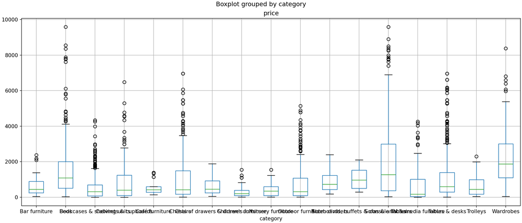

## What is there to like…

- I don’t like the title or price as a subtitle
- The labels look horrible and the x axis should be fixed

**Note**

- If you are creating a single plot in your script or notebook, you don’t need to capture the plot
- If you don’t capture a plot, it may be easier to allow matplotlib to manage the plot object.

## Example, one of many

- Technically, the more correct Pythonic way in a production situation with multiple plots is to save the plot objects then modify.

```python
bp1 = ikea.boxplot(column="price", by="category", figsize=(14, 6))

# Rotate x-axis tick labels using a for loop
for label in bp1.get_xticklabels():
    label.set_rotation(45)
    label.set_fontsize(8)
    label.set_ha('right')

# Set titles & labels
bp1.set_title("Price Distribution by Category")
bp1.set_xlabel("Category")
bp1.set_ylabel("Price")
plt.suptitle("")  # Remove default pandas title
plt.show()
```

## Example, one of many - result

- Looks the same as those not saved to an object

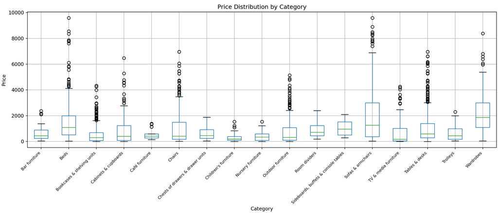

## What is get_xticklabels()?

- So we are using a for loop to modify the object matplotlib stores for the labels
- It is a list, the for loop is appropriate (as a opposed to a list comprehension) because it’s more readable and we are not returning anything or creating anything new, just modifying:

```python
print(type(bp1.get_xticklabels())) # a simple list
```

```
<class 'list'>
```

```python
print(type(bp1.get_xticklabels()[0])) # of matplotlib.text objects
```

```
<class 'matplotlib.text.Text'>
```

```python
bp1.get_xticklabels()
```

## Whew! - Recap

- Panda’s boxplot needs work when using messier data like Ikea’s catalog information
- The label solution in this situation involves a for-loop to modify the positions of the labels
- We have choices (save or not to save)
- Also note the need to suppress the defaults

## Basic Boxplot in Seaborn

- Let’s see a boxplot using Seaborn alone

```python
# adjust figure size using matplotlib
plt.figure(figsize=(14, 6))

# Create a boxplot
bp2 = sns.boxplot(x='category',
                  y='price',
                  data = ikea);
```

## Basic Boxplot in Seaborn - Result

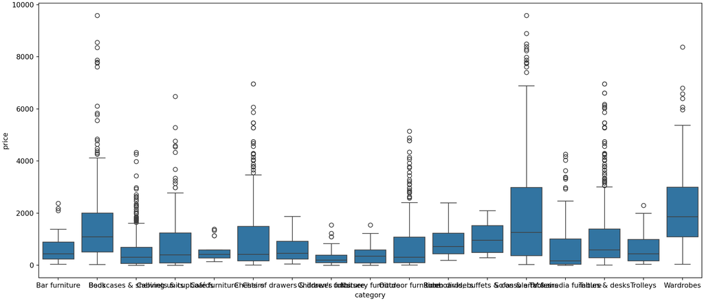

## Label modifications in Seaborn

- and changing the colors too (an additional modification with a third variable and alternating colors)

```python
bp2 = sns.boxplot(x='category',
            y='price',
            hue = 'other_colors' , # a third variable
            palette=['blue', 'orange'],
            data = ikea)

# Rotate labels
for label in bp2.get_xticklabels():
    label.set_rotation(45)
    label.set_ha('right')

# Set labels and titles
bp2.set_title("Price Distribution by Category")
bp2.set_xlabel("Category")
bp2.set_ylabel("Price")

# Show the plot
plt.show()
```

## Label modifications in Seaborn - result

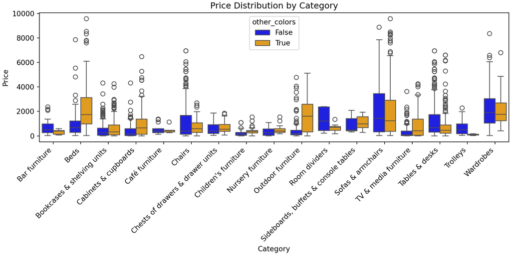

## Examining Facets

- Helps with data exploration
- Comparisons made easier
- Clarity (can reduce overplotting)
- Not specific to one industry/field

## Faceting Boxplots with Seaborn - data

- Because the furniture category has been set as a ‘category’ type
- we need to remove empty categories when we subset
- Since we are referencing to part of a DataFrame rather than a full independent copy of it we should .copy() (make a copy of the dataframe to be safe)

```python
top_categories = ikea['category'].value_counts().keys()[:4]
new_data = ikea[ikea['category'].isin(top_categories)].copy() # note this is a copy
new_data['category'] = new_data['category'].cat.remove_unused_categories()
```

## Faceting Boxplots with Seaborn

- Now facet

```python
g = sns.catplot(x='category',
                y='price',
                hue = 'category',
                col='other_colors',
                data=new_data,
                kind='box',
                height=4, aspect=1.5)

g.set_xticklabels(rotation=45, ha = 'right')

plt.show()
```

## Faceting Boxplots with Seaborn - result

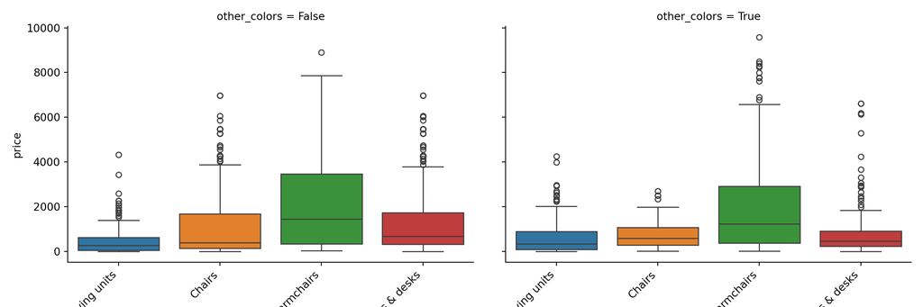

## (aside) Bad faceting with Seaborn

- if you didn’t .cat.remove_unused_categories()

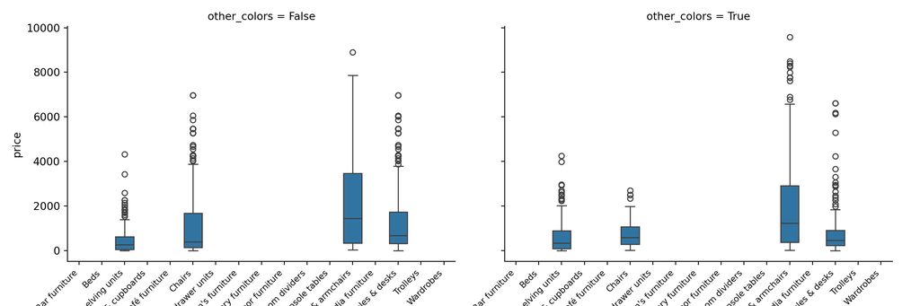

## Notes on Faceting

- In Pandas and in Matplotlib, faceting would require first creating subplots (one for each facet)
- Then process the categories in each facet, so in the Ikea example we would filter the DataFrame for a category, and then plotting the category in its designated subplot.
- If you were to avoid Seaborn, choose Matplotlib not Pandas to do this kind of work

## (Aside) Faceting with Pandas

- First you would need to define a function

```python
import pandas as pd
import matplotlib.pyplot as plt
import math

def facet_plot(df, group_col, x, y, kind='line', figsize=(8, 4), sharex=True, sharey=False, **kwargs):
    """
    Create faceted subplots for each group in `group_col`.

    Parameters:
    - df: DataFrame
    - group_col: column to group/facet by
    - x: column for x-axis
    - y: column for y-axis
    - kind: plot type ('line', 'scatter', 'bar')
    - figsize: tuple for individual subplot size
    - sharex/sharey: whether to share axes across subplots
    - kwargs: passed to pandas plot function
    """

    groups = df[group_col].unique()
    n = len(groups)

    # Calculate grid size (e.g., 3 rows x 2 columns for 6 plots)
    cols = math.ceil(math.sqrt(n))
    rows = math.ceil(n / cols)

    fig, axs = plt.subplots(rows, cols, figsize=(figsize[0] * cols, figsize[1] * rows),
                            sharex=sharex, sharey=sharey)

    axs = axs.flatten()

    for i, group in enumerate(groups):
        ax = axs[i]
        subset = df[df[group_col] == group]

        subset.plot(kind=kind, x=x, y=y, ax=ax, legend=False, **kwargs)
        ax.set_title(f"{group_col}: {group}")
        ax.set_xlabel(x)
        ax.set_ylabel(y)

    # Hide any unused subplots
    for j in range(i + 1, len(axs)):
        fig.delaxes(axs[j])

    plt.tight_layout()
    plt.show()
```

## (Aside) Faceting with Pandas (cont’d)

- Then use it. It works but we have a ways to go

```python
from sklearn.datasets import load_iris
import pandas as pd

# Load iris dataset
iris = load_iris()
df = pd.DataFrame(iris.data, columns=iris.feature_names)
df['species'] = [iris.target_names[i] for i in iris.target]

# Create faceted scatter plots
facet_plot(df, group_col='species',
           x='sepal length (cm)',
           y='sepal width (cm)',
           kind='scatter')
```

## (Aside) Faceting with Pandas Result

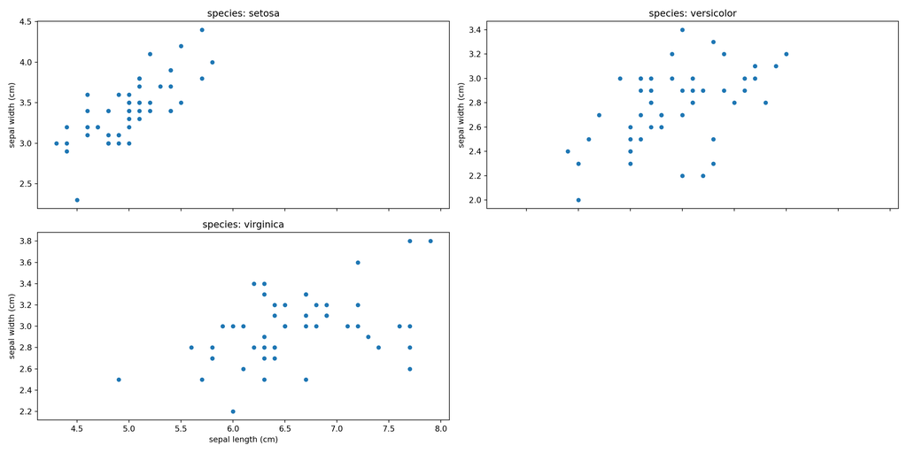

## Faceting with Seaborn

```python
import seaborn as sns
import pandas as pd
import matplotlib.pyplot as plt
from sklearn.datasets import load_iris

# Load and convert to DataFrame
iris = load_iris()
df = pd.DataFrame(iris.data, columns=iris.feature_names)
df['species'] = pd.Categorical.from_codes(iris.target, iris.target_names)

# Faceted scatterplot
g = sns.relplot(
    x='sepal length (cm)',
    y='sepal width (cm)',
    hue='species',
    col='species',
    data=df,
    kind='scatter',
    height=4, aspect=1.2, legend=False
)
```

## Faceting with Seaborn

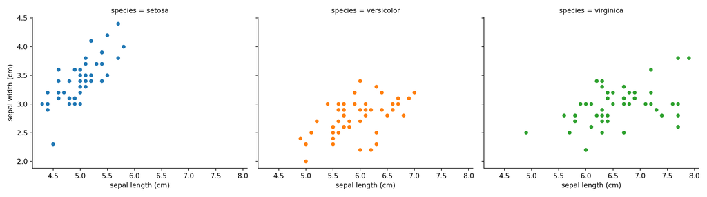

## More faceting with Seaborn

- The faceting layout is determined by col= ‘other_colors’

```python
g = sns.displot(
    data=ikea,
    x= 'price',
    col= 'other_colors',
    bins=20,
    color= 'lightblue'
)
```

## More faceting with Seaborn

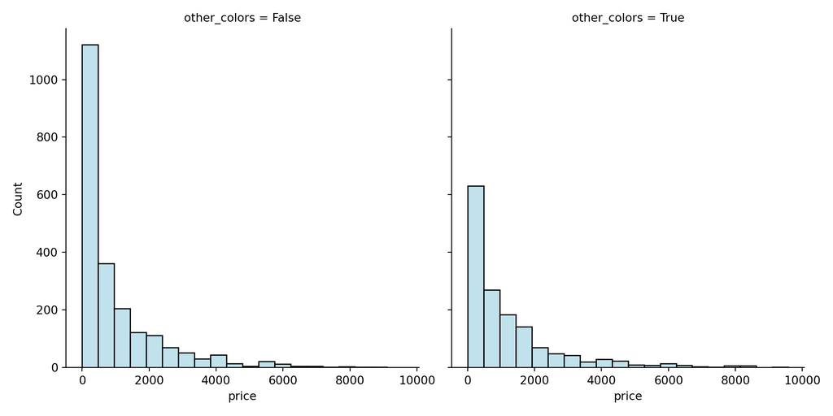

## *plotnine* Is *ggplot2*

- **plotnine** is a Python implementation of Wilkinson’s *Grammar of Graphics*, built to mirror R’s **ggplot2** syntax.
- It sits on top of **pandas**, **matplotlib**, and **mizani** (the latter handles scales and themes).
- https://plotnine.org/
- https://plotnine.org/gallery/

## plotnine details

Install it maybe:

```
pip install plotnine
```

Then:

```python
from plotnine import *
import pandas as pd
```

## Comparisons

| Concept | ggplot2 (R) | plotnine (Python) | Notes |
| --- | --- | --- | --- |
| Data | `ggplot(data)` | `ggplot(df)` | `df` is a pandas DataFrame |
| Aesthetics | `aes(x, y, color)` | `aes('x', 'y', color='var')` | Use strings for column names |
| Layers | `+ geom_point()` | `+ geom_point()` | Identical layering |
| Themes | `+ theme_minimal()` | `+ theme_minimal()` | Same theme names |
| Facets | `facet_wrap(~var)` | `facet_wrap('~var')` | String formula |
| Labels | `labs(title=, x=, y=)` | `labs(title=, x=, y=)` | Identical |
| Scales | `scale_color_brewer()` | `scale_color_brewer()` | Same |
| Save | `ggsave("plot.png")` | `ggsave(plot, "plot.png")` | Slightly different signature |

## Example: Translating from R to Python

### **R (ggplot2)**

```r
library(ggplot2)
ggplot(mpg, aes(x = displ, y = hwy, color = class)) +
  geom_point() +
  geom_smooth(method = "lm", se = FALSE) +
  facet_wrap(~drv) +
  theme_minimal()
```

## Example: Translating from R to Python

### **Python (plotnine)**

```python
from plotnine import *
from plotnine.data import mpg

(
    ggplot(mpg, aes('displ', 'hwy', color='class'))
    + geom_point()
    + geom_smooth(method='lm', se=False)
    + facet_wrap('~drv')
    + theme_minimal()
)
```

Use parentheses to wrap the full expression, since Python doesn’t support line continuation via `+` like R.

## Differences in Data Handling

- **pandas** parallels **dplyr**: Perform transformations in pandas before passing to plotnine:

  ```python
  df2 = df.query("year == 2024").assign(ratio=lambda d: d['value1']/d['value2'])
  ggplot(df2, aes('x', 'ratio')) + geom_col()
  ```

- **Factor levels**: R has built-in `factor` order; in Python, use `CategoricalDtype`

## Gotchas

| Issue | R way | plotnine fix |
| --- | --- | --- |
| Non-string aesthetics | `aes(x = mpg, y = wt)` | `aes('mpg', 'wt')` |
| String concatenation | `paste()` | `+` or f-strings |
| Displaying plot | Implicit in RStudio | Explicit `print(plot)` in Python |
| Themes | Use `theme_*` functions | Mostly identical, but a few (e.g. `theme_gray`) differ slightly |
| Saving | `ggsave()` auto-saves last plot | You must pass the plot object: `ggsave(plot, 'file.png')` |

## Python Beyond ggplot2

plotnine gives you:

- **Interactive save/display** via matplotlib.
- Access to **matplotlib backends** (e.g., Jupyter inline display).
- **Custom Python logic**: integrate seamlessly with numpy/pandas/scikit-learn.

Example:

```python
from sklearn.linear_model import LinearRegression
import numpy as np

model = LinearRegression().fit(mpg[['displ']], mpg['hwy'])
mpg['pred'] = model.predict(mpg[['displ']])

(
    ggplot(mpg, aes('displ', 'hwy'))
    + geom_point()
    + geom_line(aes(y='pred'), color='red')
)
```

## Geoms

| Purpose | **ggplot2 (R)** | **plotnine (Python)** |
| --- | --- | --- |
| Scatter | `geom_point()` | `geom_point()` |
| Line | `geom_line()` | `geom_line()` |
| Smooth (trend) | `geom_smooth(method = "lm")` | `geom_smooth(method='lm')` |
| Histogram | `geom_histogram(binwidth = 1)` | `geom_histogram(binwidth=1)` |
| Density | `geom_density()` | `geom_density()` |
| Bar | `geom_bar()` | `geom_bar()` |
| Boxplot | `geom_boxplot()` | `geom_boxplot()` |
| Violin | `geom_violin()` | `geom_violin()` |
| Text | `geom_text(aes(label = name))` | `geom_text(aes(label='name'))` |
| Jitter | `geom_jitter(width = .1)` | `geom_jitter(width=.1)` |

## Aesthetics (`aes()`)

| Mapping | **ggplot2 (R)** | **plotnine (Python)** |
| --- | --- | --- |
| Basic | `aes(x = displ, y = hwy)` | `aes('displ', 'hwy')` |
| Color | `aes(color = class)` | `aes(color='class')` |
| Size | `aes(size = cyl)` | `aes(size='cyl')` |
| Shape | `aes(shape = drv)` | `aes(shape='drv')` |
| Fill | `aes(fill = class)` | `aes(fill='class')` |
| Alpha | `aes(alpha = hwy)` | `aes(alpha='hwy')` |

## Facets is the same

| Type | **ggplot2 (R)** | **plotnine (Python)** |
| --- | --- | --- |
| Wrap | `facet_wrap(~class)` | `facet_wrap('~class')` |
| Grid | `facet_grid(drv ~ cyl)` | `facet_grid('drv ~ cyl')` |

## Saving Plots

| Task | **ggplot2 (R)** | **plotnine (Python)** |
| --- | --- | --- |
| Save | `ggsave("plot.png")` | `ggsave(plot, "plot.png", dpi=300)` |
| Different format | `ggsave("plot.pdf")` | `ggsave(plot, "plot.pdf")` |

## Same Plot in R and Python Plotnine

**R**

```r
ggplot(mpg, aes(displ, hwy, color = class)) +
  geom_point() +
  geom_smooth(method = "lm", se = FALSE) +
  facet_wrap(~drv) +
  labs(title = "Fuel Efficiency by Drive Type") +
  theme_minimal()
```

**Python**

```python
from plotnine import *
from plotnine.data import mpg

(
    ggplot(mpg, aes('displ', 'hwy', color='class'))
    + geom_point()
    + geom_smooth(method='lm', se=False)
    + facet_wrap('~drv')
    + labs(title='Fuel Efficiency by Drive Type')
    + theme_minimal()
)
```

## ggplot in Python is plotnine

```python
import plotnine as p9
# import plotnine as *

(
    p9.ggplot(mtcars,
        p9.aes('wt', 'mpg', color='factor(gear)'))
    + p9.geom_point()
    + p9.facet_wrap('gear')
    + p9.stat_smooth(method='lm')
    + p9.ggtitle('mpg on wt faceted by gear')
    + p9.theme_bw()
)
```

```
<plotnine.ggplot.ggplot object at 0x3188b1fd0>
```

## plotnine considerations

- It is a port of ggplot
- Modifications are ggplot, NOT matplotlib based

```python
(p9.ggplot(ikea,
    p9.aes('category',
        'price',
        fill='category'))
    + p9.geom_boxplot()

    + p9.ggtitle(title='Comparison of Price Across Category')
    + p9.theme_bw()
    + p9.theme(legend_position='none',
                figure_size=(10, 6),
                axis_text_x = p9.element_text(angle=45, size = 6,
                va='top', ha='right'))
)
```

```
<plotnine.ggplot.ggplot object at 0x313efe120>
```

## layering with plotnine

```python
import plotnine as p9

(
    p9.ggplot(ikea,
        p9.aes('category', 'price', fill='category'))
    + p9.geom_boxplot()

    + p9.stat_summary(
        fun_y=np.mean,
        geom='line',
        group=1,
        color='red',
        size=1
    )
    + p9.stat_summary(
        fun_y=np.mean,
        geom='point',
        color='black',
        size=2
    )

    + p9.ggtitle(title='Comparison of Price Across Category')
    + p9.theme_bw()
    + p9.theme(
        figure_size=(10, 6),
        legend_position='none',
        axis_text_x=p9.element_text(angle=45, size=6, va='top', ha='right')
    )
)
```

```
<plotnine.ggplot.ggplot object at 0x318982690>
```

## Same in seaborn

```python
import seaborn as sns
import matplotlib.pyplot as plt
import pandas as pd
import numpy as np

# Assuming ikea is already loaded
# Calculate the means per category
mean_df = (
    ikea.groupby("category", as_index=False)["price"]
    .mean()
    .rename(columns={"price": "mean_price"})
)

# Create the boxplot
plt.figure(figsize=(10, 6))
ax = sns.boxplot(data=ikea, x="category", y="price", palette="pastel")

# Add mean points
sns.scatterplot(
    data=mean_df,
    x="category",
    y="mean_price",
    color="black",
    s=40,
    zorder=10,
    ax=ax,
    marker='o'
)

# Add connecting line between mean points
sns.lineplot(
    data=mean_df,
    x="category",
    y="mean_price",
    color="red",
    linewidth=1,
    zorder=9,
    ax=ax
)

# Customize appearance
plt.title("Comparison of Price Across Category\nWith means plotted and connected")
plt.xticks(rotation=45, ha='right', fontsize=6)
#ax.legend_.remove()  # Remove legend
plt.show()
```

## Same in seaborn - result

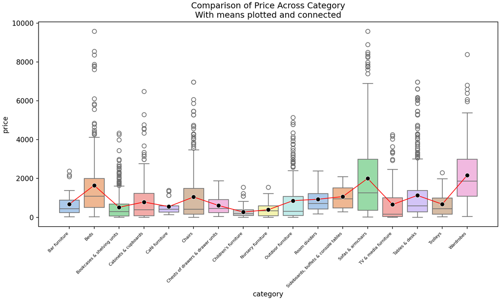

## a plot with no name

```python
(
    p9.ggplot(ikea, p9.aes('price'))
    + p9.geom_histogram(p9.aes(y='..density..'), fill='blue', color='black', alpha=0.5, bins=30)
    + p9.geom_density(color='red', size=1)
    + p9.facet_wrap('other_colors')
    + p9.ggtitle(title='Comparison of Price Across Colors')
    + p9.theme_538()
    + p9.theme(
        figure_size=(10, 6),
        legend_position='none')
)
```

```
<plotnine.ggplot.ggplot object at 0x3140d6a50>
```

## seaborn’s version

```python
import seaborn as sns
import matplotlib.pyplot as plt
from matplotlib import style
plt.style.use('ggplot')

# Create FacetGrid manually
g = sns.FacetGrid(
    data=ikea,
    col="other_colors",
    height=3,
    aspect=1
)

# Add histogram and KDE manually
g.map(
    sns.histplot,
    data = ikea,
    x="price",
    bins=30,
    color="blue",
    edgecolor="black",
    alpha=0.5,
    stat='density'
)

# Add histogram and KDE manually
g.map(
    sns.kdeplot,
    data = ikea,
    x="price",
    color="red"
)
# Set a title
g.fig.suptitle("Comparison of Price Across Colors", fontsize=12)
plt.subplots_adjust(top=0.85)
plt.show()
```

## seaborn’s version result

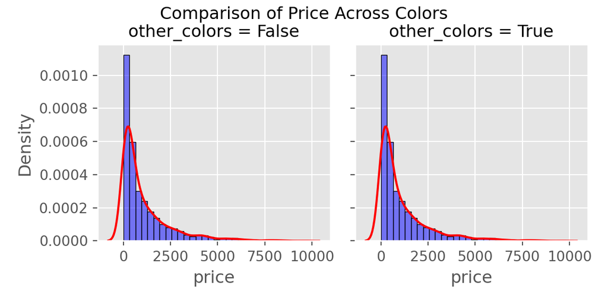

# other parts of the grammar

## Aesthetics (Aesthetic Mappings)

- These are the rules for the visualization
- The aesthetics map (connect) data variables to the visual properties of the graphical elements
- Most frequently - x, y, color, size, and shape
- The connection of data to graphical elements allow us to see/interpret patterns, trends, and anomalies within the data

## Aesthetic - Example

- strange, I know, but the aesthetic does not need to be global (top line) but can be in each geom giving a lot of flexibility

```python
import pandas as pd
import plotnine as p9
from sklearn.datasets import load_iris

# Load and convert to DataFrame
iris = load_iris()
df = pd.DataFrame(iris.data, columns=iris.feature_names)
df['species'] = pd.Categorical.from_codes(iris.target, iris.target_names)

(
    p9.ggplot(df)
    + p9.geom_point(p9.aes('sepal length (cm)', 'sepal width (cm)'), color = 'blue')
    + p9.geom_point(p9.aes('sepal width (cm)', 'sepal length (cm)'), color = 'red', shape = 'D')
    + p9.geom_smooth(p9.aes('sepal width (cm)', 'sepal length (cm)'),color = 'yellow', size =3)
    + p9.geom_smooth(p9.aes('sepal length (cm)', 'sepal width (cm)'),color = 'yellow', size =3)
    + p9.facet_wrap('species')
    + p9.ggtitle(title='flipping aesthetics')
    + p9.theme(
        figure_size=(10, 6),
        legend_position='none')
)
```

```
<plotnine.ggplot.ggplot object at 0x3188d8d10>
```

## Geoms (Geometries) include

- Points, typically used for individual values
- Lines, connect points in some defined order (e.g., time, location)
- Bars, typically used for categories (e.g., pizza types)
- Polygons, used to represent areas (e.g., maps)
- Paths, fatter lines, used to represent flows

## Geoms

```python
import pandas as pd
import numpy as np
import plotnine as p9
from plotnine.data import mpg

df = mpg.copy()

# Create a plot with multiple geoms
# - Violin plot for distribution
# - a tiny boxplot inside for summary
# - jitter points to show individual cars
# - the mean point highlighted

p = (
    p9.ggplot(df, p9.aes(x='class', y='hwy', fill='class'))
    + p9.geom_violin(alpha=0.3)
    + p9.geom_boxplot(width=0.2, outlier_shape=None, alpha=0.6)
    + p9.geom_jitter(p9.aes(color='class'), width=0.15, size=1.5, alpha=0.5)
    + p9.stat_summary(fun_y=np.mean, geom='point', fill='black', size=3, shape='o')
    + p9.labs(
        title='Highway MPG by Vehicle Class',
        x='Class',
        y='MPG'
    )
    + p9.theme_bw()
    + p9.theme(axis_text_x=p9.element_text(rotation=45, hjust=1))
)

# Show the plot object
p
```

```
<plotnine.ggplot.ggplot object at 0x3189822d0>
```

## Facets and Layers

- Condition the data with facets and layers
- Subsets are called facets
- Layers combine multiple types of visualizations into a single graphic

## Statistics

- Data can be summarized or modified prior to visualization examples:
  - Aggregation (like sums or means)
  - smoothing
- Having these can clarify the underlying structure or relationships in data.

## Coordinates and scales

- Coordinate systems (Cartesian, polar, etc.).
- Scaling (linear, logarithmic, etc.)
- They influence the position of data points
- And possibly help interpretation

## Rescaling

```python
import plotnine as p9
from plotnine.data import mpg

# Example: Scaling in action
p = (
    p9.ggplot(mpg, p9.aes(x='displ', y='hwy', color='class'))
    + p9.geom_point(size=3, alpha=0.7)
    + p9.scale_color_brewer(type='qual', palette='Set2')  # Categorical color palette
    + p9.labs(
        title="Engine Displacement vs. Highway MPG",
        x="Engine Size",
        y="Highway MPG",
        color="Vehicle Class"
    )
    + p9.theme_bw()
)
p + p9.scale_x_reverse()
```

```
<plotnine.ggplot.ggplot object at 0x3140d5490>
```

## Themes

- Control the overall “look” of the graphic
- fonts, colors, gridlines
- labeling, legends, captioning
- layout etc.

## Pandas, Seaborn, Matplotlib

| Library | Grammar of Graphics Model? | Description |
| --- | --- | --- |
| **`matplotlib`** | No, opposite of GG | Imperative, low-level, procedural not grammar-based |
| **`pandas.plot`** | No, Very limited mapping | Thin wrapper over matplotlib; minimal aesthetics mapping |
| **`seaborn`** | Semi-grammatical | High-level API inspired by GoG, but not fully declarative |
| **`plotnine` (Python)** | Full GG | A direct port of `ggplot2` |
| **`ggplot2` (R)** | Full GG implementation | fully declarative |